# 某營隊學習效果及問卷優化研究–簡潔版結果

Hung-Che Lee

本研究旨在協助問卷設計者，透過受試者的作答結果，分析不同族群在各題項上的表現差異、課程前後的變化，以及找出可能影響學習成效的潛在關鍵因素。藉由上述分析，期望能以數據為依據，優化題目敘述，並進行題項增刪，進一步提升未來問卷施測的效率與成效。

本研究資料來源為某營隊活動所實施之問卷調查，問卷內容圍繞課程設計，分別於課程開始前（前測）與結束前（後測）施測。以下為受試者之個人特質與背景資料的敘述統計摘要：

- **有效樣本數**：146 人（原始樣本為 156 人，已剔除遺失值過多或大部分題目均疑似隨機作答者共 10 人）
- **梯次**：第一批學校 107 人；第二批學校 39 人
- **教育階段**：國中 88 人；高中 58 人
- **性別**：男性 79 人；女性 67 人

針對「早餐學習單」資料，因非所有受試者皆回填，故以下統計僅涵蓋具有效填答者（共 109 人）：

- **是否肥胖**：肥胖者 20 人；非肥胖者 89 人
- **早餐熱量攝取**：高熱量攝取者（≥500 kcal）23 人；低熱量攝取者（<500 kcal）86 人
- **早餐來源**：超商 75 人；早餐店 17 人；自宅 17 人

由於是非題（有正確答案）與態度題（僅知同意/不同意的程度）的題目類型差異，後續的分析會將這兩大類題目分開。

本篇僅節錄部分分析結果。

態度題分析待更

```r
# 態度題分析放各題占比變化 & 各題mcnemar
# 匯入預處理資料
# （C表示合併所有學校, dat1前測, dat2後測, _yn表示生物/技術是非題資料,
#  .ju表示國中, .se表示高中, .st表示答案轉成正確錯誤）

setwd("C:/Users/h2407/OneDrive/文件/師培中心分析案")

Cdat1_yn<-readRDS("./分析用資料/Cdat1_yn")
Cdat2_yn<-readRDS("./分析用資料/Cdat2_yn")

# 重新整理國高中資訊，僅作為挑選ID用
Cdat1_yn.ju<-readRDS("./分析用資料/Cdat1_yn.ju")
Cdat1_yn.se<-readRDS("./分析用資料/Cdat1_yn.se")

Cdat1_yn.st<-readRDS("./分析用資料/Cdat1_yn.st")
Cdat2_yn.st<-readRDS("./分析用資料/Cdat2_yn.st")

# 匯入答案
ans<-read_xlsx("./data_record_和平桃農.xlsx")[1,-c(1:4,35:44,55:67)]

# 分成生物題/技術題
ans_bio<-ans[1:30]
ans_tech<-ans[31:40]

# 將正確錯誤以label encoding表示

Cdat1_yn.st.mat<-Cdat1_yn.st[names(ans)] %>%
  dplyr::mutate(across(everything(), ~case_when(
    trimws(.) == "正確" ~ 1,
    trimws(.) == "錯誤" ~ 0,
    TRUE ~ NA_real_
  )))

Cdat2_yn.st.mat<-Cdat2_yn.st[names(ans)] %>%
  dplyr::mutate(across(everything(), ~case_when(
    trimws(.) == "正確" ~ 1,
    trimws(.) == "錯誤" ~ 0,
    TRUE ~ NA_real_
  )))

Cdat_yn.st.mat<-rbind(Cdat1_yn.st.mat, Cdat2_yn.st.mat)


# # 題目簡寫
# ans0<-str_replace_all(names(ans),"是非","")

## 匯入早餐學習單資料
eat<-read_xlsx("./早餐學習單_兩批彙整.xlsx",skip=1)%>%as.data.frame()

# 匯入並處理性質分類資料
typee<-read_xlsx("./問卷性質標註2.xlsx")%>%as.data.frame()
rownames(typee)<-typee$...1; typee<-typee[,-1]
typee$是否為覺察題[is.na(typee$是否為覺察題)] = ""

# # 匯入生是非知識性質、覺察分類資訊
# typee_bio<-readRDS("./分析用資料/typee")
#
# # 第二種覺察分類
# typee_bio$sense2<-0
# typee_bio$sense2[c(6,7,9,12,15,18:20,23,26:28)]<-1

## 匯入functions
source("./functions_通用版.R")
```

```r
# 各種分組

## 教育階段
Cju = Cdat1_yn$流水號%in%Cdat1_yn.ju$流水號
Cse = Cdat1_yn$流水號%in%Cdat1_yn.se$流水號

## 性別
Cboy<-Cdat1_yn$流水號%in%(eat%>%filter(性別=="男"))$流水號

## 肥胖
Cfat<-Cdat1_yn$流水號%in%eat[which(eat$`平均一餐熱量需求(kcal)`>=700),]$流水號
Cnofat<-Cdat1_yn$流水號%in%eat[which(eat$`平均一餐熱量需求(kcal)`<700),]$流水號

## 早餐高熱量
Cfat.bf<-Cdat1_yn$流水號%in%eat[which(eat$`早餐總熱量(kcal)`>=500),]$流水號
Cnofat.bf<-Cdat1_yn$流水號%in%eat[which(eat$`早餐總熱量(kcal)`<500),]$流水號

## 早餐來源
C711<-Cdat1_yn$流水號%in%(eat%>%filter(可能早餐來源%in%str_subset(eat$可能早餐來源%>%unique(),"超商")))$流水號
Cbf<-Cdat1_yn$流水號%in%(eat%>%filter(可能早餐來源%in%str_subset(eat$可能早餐來源%>%unique(),"傳統早餐店")))$流水號
Chome<-Cdat1_yn$流水號%in%(eat%>%filter(可能早餐來源%in%str_subset(eat$可能早餐來源%>%unique(),"家裡")))$流水號

# 生物/技術是非題的分類
bio <- tibble(
  type = c("全部生物是非", "知識", "推論", "計算", "覺察"),
  ques_name = list(names(ans_bio),
              names(ans_bio)[typee$主題分類=='知識'],
              names(ans_bio)[typee$主題分類=='推論'],
              names(ans_bio)[typee$主題分類=='計算'],
              names(ans_bio)[typee$是否為覺察題=='覺察'])
)

tech <- tibble(
  type = c("全部技術是非", "電子感測", "Arduino", "程式"),
  ques_name = list(names(ans_tech),
              names(ans_tech)[c(1,3,4)],
              names(ans_tech)[c(2,5,6,7)],
              names(ans_tech)[c(8,9,10)])
)
```

# 1 是非題分析

以下為是非題各題之題目敘述與主題分類，後續分析將以各題答對率為核心指標進行探討（填答「不知道」或未作答者皆視為答錯）。我們將依據不同主題分類，結合受試者之個人特徵，逐步分析其在前測與後測中的表現變化。

分析將涵蓋多種受試者分組變項，包括性別、教育階段、早餐熱量需求等，進一步探討各主題類型在不同族群之間的學習差異與成效，藉此辨識潛在影響學習表現的關鍵因素。

```r
typee%>%kable("html", row.names = T, escape = F,booktabs = TRUE, caption="是非題題目與對應的主題分類")%>%
  kable_styling(c("striped", "bordered"))%>%
  column_spec(1, bold = T)%>%
  collapse_rows(columns = c(1))%>%
  group_rows("生物是非", 1, 30)%>%
  group_rows("技術是非", 31, 40)
```

是非題題目與對應的主題分類

|  | 題目 | 主題分類 | 是否為覺察題 |
| --- | --- | --- | --- |
| **生物是非** |  |  |  |
| 生1 | 提供人體能量主要來源的營養素是醣類 | 知識 |  |
| 生2 | 吃很多含糖食品或飲料，能有充分的養分提供人體所需 | 知識 | 覺察 |
| 生3 | 身體內多餘的葡萄糖會轉成肝糖與脂肪 | 推論 |  |
| 生4 | 醣類、脂肪、蛋白質所能夠產生的能量是相同的 | 知識 |  |
| 生5 | 胰島素可以增進細胞對於葡萄糖的吸收 | 知識 |  |
| 生6 | 奶茶與蛋餅是營養均衡的早餐選擇 | 知識 | 覺察 |
| 生7 | 青少年每日所需之營養量，與活動量相關 | 知識 |  |
| 生8 | 在特殊時候，胺基酸與脂肪酸也能在人體中轉變成葡萄糖，或參與能量產生 | 推論 |  |
| 生9 | 超商無糖飲料不會發胖，不會對身體造成健康負擔 | 推論 | 覺察 |
| 生10 | 細胞在高血糖血液裡容易誘發氧化，導致細胞死亡 | 推論 |  |
| 生11 | 睡眠不足容易發胖的原因是因為胰島素過度分泌 | 推論 | 覺察 |
| 生12 | 吃水果與喝果汁，在體內轉成葡萄糖速度是一樣的 | 推論 | 覺察 |
| 生13 | 糖尿病人通常肥胖，有心血管疾病，嚴重需要截肢 | 知識 | 覺察 |
| 生14 | 造成糖尿病的原因是胰島素分泌過多 | 知識 |  |
| 生15 | 細嚼慢嚥有助於人體平緩地獲得血糖 | 推論 | 覺察 |
| 生16 | 用水果取代正餐，吃得少又健康 | 推論 | 覺察 |
| 生17 | 甜點在飯前與飯後吃，對於體內葡萄糖的影響一樣 | 推論 | 覺察 |
| 生18 | 吃精緻澱粉相較未加工的全榖雜糧類更富含營養，更健康 | 知識 | 覺察 |
| 生19 | 身體如果沒有感覺到不舒服，表示身體的血糖狀況非常穩定 | 推論 | 覺察 |
| 生20 | 在正餐之間吃零食會讓胰島素經常處在高度分泌狀況 | 推論 | 覺察 |
| 生21 | 當胰島素分泌細胞受損，胰島素分泌量不足可造成糖尿病 | 推論 |  |
| 生22 | 第二型糖尿病的早期原因是細胞對於胰島素吸收不良 | 推論 |  |
| 生23 | 先吃蔬菜再吃米飯會讓血糖上升幅度比較小 | 推論 | 覺察 |
| 生24 | 若青少年一天所需的熱量為2000大卡，醣類攝取量應為500大卡 | 計算 |  |
| 生25 | 身高160公分的國中生，若BMI為24，體重大約是50公斤 | 計算 |  |
| 生26 | 血糖逐漸失控的狀況，可以從腰圍看出來，若腰圍超過90公分，則有糖尿病風險 | 計算 | 覺察 |
| 生27 | 運動能幫助人體消耗能量，對於降低血糖波動有幫助 | 推論 | 覺察 |
| 生28 | 如果空腹血糖超過120mg/dL就表示可能有糖尿病 | 計算 |  |
| 生29 | 使用血糖計量測血糖時會用到測試紙 | 知識 |  |
| 生30 | 一個麥香雞堡的熱量大約430大卡 | 計算 |  |
| **技術是非** |  |  |  |
| 技1 | 使用電子材料可以自己做溫度感測器 | 電子感測 |  |
| 技2 | Arduino IDE 程式是開源軟體 | Arduino |  |
| 技3 | 透過光學可以設計器材來偵測心跳 | 電子感測 |  |
| 技4 | 透過電的傳導可以用來偵測葡萄糖濃度 | 電子感測 |  |
| 技5 | 麵包板能通電的原因是因為後面有貼金屬片 | Arduino |  |
| 技6 | Arduino板子上有數位腳位與類比腳位 | Arduino |  |
| 技7 | Arduino通常使用5V的電壓 | Arduino |  |
| 技8 | 在程式中要使用變數之前要先定義 | 程式 |  |
| 技9 | 在Arduino IDE 程式中要確認有加裝需要的函式庫(library) | 程式 |  |
| 技10 | 程式設計中如果有loop表示迴圈要不斷執行 | 程式 |  |

當每個主題分類包含多個題目時，若我們希望**同時檢定多個題目在前後測之間的差異**，可使用 t 檢定的多變量擴展形式——**Hotelling’s T² 檢定**。Hotelling’s T² 是經典的多變量假設檢定方法，用於比較兩組樣本在多個變項（變數）上的整體差異。當只有單變項時，Hotelling’s T² 退化為雙樣本 t 檢定，因此可視為其自然推廣。

與單變項的 t 檢定不同，Hotelling’s T² 檢定同時納入變項間的**共變異數結構**，可有效控制變項間的相關性對檢定結果的影響，進而提升統計效率並降低型一錯誤率，特別適用於題目彼此可能高度相關的情境。

在本研究中，Hotelling’s T² 主要應用於下列兩種情境：

- **雙樣本 Hotelling’s T²**：比較兩組獨立樣本（如不同性別、教育階段、早餐攝取組別）在多個題目的平均答對率是否存在整體顯著差異。此檢定需先確認兩組樣本的共變異數是否相等（如使用 Box’s M 檢定），以決定是否可採 pooled covariance。
- **成對 Hotelling’s T²**：比較相依樣本（前測/後測）在多個題目的平均答對率是否存在顯著差異。

以下展示Hotelling’s T²檢定的類型、對應的公式及用法（假設 $\mathbf{X}, \mathbf{Y}$ 為兩組樣本之資料矩陣，維度分別為 $n_X \times p$ 與 $n_Y \times p$ ，共變異數矩陣分別為 $\mathbf{S}_X, \mathbf{S}_Y$）：

[output not shown]

## 1.1 全部人

### 1.1.1 表1-1-1：生物題各主題分類之前後測（全部人）

```r
df_bio <- Map(function(tp, name) {
  yn_lifes.prepost.compare.table(
    Cdat1_yn.st.mat, Cdat2_yn.st.mat,
    # type = tp,
    pair = T,
    ques_name = name
)[[1]]
}, tp = bio$type, name = bio$ques_name) %>%
  do.call(rbind, .)

colnames(df_bio)[1:4] = c("Mean", "SD", "Mean", "SD")
df_add_sig_stars(as.data.frame(df_bio))%>%kable("html", row.names = T, escape = F,booktabs = TRUE, caption=" 全部生物是非題/知識性質與覺察分類前後測整體表現（全部人n=146）",
                    digits=c(3,2,3,2,3,2,3))%>%
  kable_styling(c("striped", "bordered"))%>%
  add_header_above(c(" " = 1, "前測答對率" = 2, "後測答對率" = 2, "Hotelling T2檢定\n（進步量）"=3))%>%
  column_spec(1, bold = T)%>%
  collapse_rows(columns = c(1))
```

全部生物是非題/知識性質與覺察分類前後測整體表現（全部人n=146）

|  | 前測答對率 Mean | 前測答對率 SD | 後測答對率 Mean | 後測答對率 SD | Hotelling T2檢定 （進步量） Mean Diff | Hotelling T2檢定 （進步量） T2 Stat | Hotelling T2檢定 （進步量） p-value |
| --- | --- | --- | --- | --- | --- | --- | --- |
| 全部生物是非 | 0.619 | 0.15 | 0.715 | 0.15 | 0.096 | 207.90 | 0.000*** |
| 知識 | 0.711 | 0.17 | 0.771 | 0.18 | 0.060 | 79.43 | 0.000*** |
| 推論 | 0.645 | 0.17 | 0.736 | 0.17 | 0.091 | 81.75 | 0.000*** |
| 計算 | 0.356 | 0.27 | 0.542 | 0.25 | 0.186 | 64.34 | 0.000*** |
| 覺察 | 0.684 | 0.18 | 0.775 | 0.19 | 0.091 | 119.49 | 0.000*** |

### 1.1.2 表1-1-2：技術題各主題分類之前後測（全部人）

```r
df_tech <- Map(function(tp, name) {
  yn_lifes.prepost.compare.table(
    Cdat1_yn.st.mat, Cdat2_yn.st.mat,
    # type = tp,
    pair = T,
    ques_name = name
)[[1]]
}, tp = tech$type, name = tech$ques_name) %>%
  do.call(rbind, .)

colnames(df_tech)[1:4] = c("Mean", "SD", "Mean", "SD")
df_add_sig_stars(as.data.frame(df_tech))%>%kable("html", row.names = T, escape = F,booktabs = TRUE, caption=" 全部技術是非題/各技術類別前後測整體表現（全部人n=146）",
                    digits=c(3,2,3,2,3,2,3))%>%
  kable_styling(c("striped", "bordered"))%>%
  add_header_above(c(" " = 1, "前測答對率" = 2, "後測答對率" = 2, "Hotelling T2檢定\n（進步量）"=3))%>%
  column_spec(1, bold = T)%>%
  collapse_rows(columns = c(1))
```

全部技術是非題/各技術類別前後測整體表現（全部人n=146）

|  | 前測答對率 Mean | 前測答對率 SD | 後測答對率 Mean | 後測答對率 SD | Hotelling T2檢定 （進步量） Mean Diff | Hotelling T2檢定 （進步量） T2 Stat | Hotelling T2檢定 （進步量） p-value |
| --- | --- | --- | --- | --- | --- | --- | --- |
| 全部技術是非 | 0.375 | 0.29 | 0.787 | 0.26 | 0.412 | 307.70 | 0.000*** |
| 電子感測 | 0.507 | 0.35 | 0.858 | 0.26 | 0.352 | 117.44 | 0.000*** |
| Arduino | 0.274 | 0.32 | 0.774 | 0.30 | 0.500 | 282.97 | 0.000*** |
| 程式 | 0.377 | 0.38 | 0.733 | 0.33 | 0.356 | 109.62 | 0.000*** |

由表 1-1-1 與表 1-1-2 可觀察到，無論合併所有題目或依各主題分類，生物與技術是非題在前後測表現皆有顯著提升，顯示營隊課程在促進學生學習上具實質成效。而技術題進步量又較生物題明顯，表示課程對技術概念的傳授成效顯著。就主題分類來看，計算題的答對率較低，後測平均答對率也僅有0.5左右。

為深入瞭解各題型的學習困難與成效差異，後續分析需結合受試者特徵（如性別、教育階段等）與逐題表現，進一步探討影響學習成效的關鍵因子，亦有助於未來課程內容與施測設計之優化。

## 1.2 按教育階段分組（國中/高中）

### 1.2.1 表1-2-1：生物題各主題分類之前後測（按教育階段分組）

```r
df_bio_edu <- Map(function(tp, name) {
  yn_lifes.prepost.compare.all.table(
    Cdat1_yn.st.mat%>%filter(Cju), Cdat2_yn.st.mat%>%filter(Cju),
    Cdat1_yn.st.mat%>%filter(Cse), Cdat2_yn.st.mat%>%filter(Cse),
    state = 1,  #教育階段
    type = tp,
    pair = T,
    ques_name = name,
    comparetest = T
  )
}, tp = bio$type, name = bio$ques_name) %>%
  do.call(rbind, .)

df_add_sig_stars(df_bio_edu)%>%kable("html", row.names = FALSE, escape = F,booktabs = TRUE, caption=" 全部生物是非題/知識性質與覺察分類前後測整體表現（國中n=88 vs. 高中n=58）",
                    digits=c(0,0,3,2,3,2,3,2,3,3,2,3,3,2,3,3,2,3))%>%
  kable_styling(c("striped", "bordered"))%>%
  add_header_above(c(" " = 2, "前測答對率" = 2, "後測答對率" = 2, "Hotelling T2檢定\n（進步量）"=3,
                     "Hotelling T2檢定\n（高中前測-國中前測）"=3,  "Hotelling T2檢定\n（高中後測-國中後測）"=3,
                     "Hotelling T2檢定\n（高中進步量-國中進步量）"=3))%>%
  column_spec(1, bold = T)%>%
  collapse_rows(columns = c(1,10:18))
```

全部生物是非題/知識性質與覺察分類前後測整體表現（國中n=88 vs. 高中n=58）

| 題目 | 教育階段 | 前測答對率 Mean | 前測答對率 SD | 後測答對率 Mean | 後測答對率 SD | Hotelling T2檢定 （進步量） Mean Diff | Hotelling T2檢定 （進步量） T2 Stat | Hotelling T2檢定 （進步量） p-value | Hotelling T2檢定 （高中前測-國中前測） Mean Diff | Hotelling T2檢定 （高中前測-國中前測） T2 Stat | Hotelling T2檢定 （高中前測-國中前測） p-value | Hotelling T2檢定 （高中後測-國中後測） Mean Diff | Hotelling T2檢定 （高中後測-國中後測） T2 Stat | Hotelling T2檢定 （高中後測-國中後測） p-value | Hotelling T2檢定 （高中進步量-國中進步量） Mean Diff | Hotelling T2檢定 （高中進步量-國中進步量） T2 Stat | Hotelling T2檢定 （高中進步量-國中進步量） p-value |  |  |  |  |  |  |  |  |  |  |  |  | … |
| --- | --- | --- | --- | --- | --- | --- | --- | --- | --- | --- | --- | --- | --- | --- | --- | --- | --- | --- | --- | --- | --- | --- | --- | --- | --- | --- | --- | --- | --- | --- |
| 全部生物是非 | 國中 | 0.590 | 0.15 | 0.692 | 0.17 | 0.103 | 217.11 | 0.000*** | 0.073 | 58.61 | 0.050* | 0.058 | 64.12 | 0.022* | -0.016 | 34.50 | 0.592 |  |  |  |  |  |  |  |  |  |  |  |  | … |
|  | 高中 | 0.663 | 0.15 | 0.750 | 0.12 | 0.087 | 103.61 | 0.082 |  |  |  |  |  |  |  |  |  |  |  |  |  |  |  |  |  |  |  |  |  | … |
| 知識 | 國中 | 0.685 | 0.18 | 0.752 | 0.20 | 0.067 | 48.66 | 0.000*** |  |  |  |  |  |  |  |  |  | 0.065 | 15.92 | 0.149 | 0.046 | 23.92 | 0.019* | -0.019 | 9.53 | 0.541 |  |  |  | … |
|  | 高中 | 0.750 | 0.16 | 0.798 | 0.14 | 0.048 | 53.59 | 0.000*** |  |  |  |  |  |  |  |  |  |  |  |  |  |  |  |  |  |  |  |  |  | … |
| 推論 | 國中 | 0.617 | 0.17 | 0.714 | 0.19 | 0.096 | 74.23 | 0.000*** | 0.070 | 24.94 | 0.114 | 0.056 | 25.65 | 0.099 | -0.013 | 15.96 | 0.500 |  |  |  |  |  |  |  |  |  |  |  |  | … |
|  | 高中 | 0.687 | 0.16 | 0.770 | 0.14 | 0.083 | 27.32 | 0.204 |  |  |  |  |  |  |  |  |  |  |  |  |  |  |  |  |  |  |  |  |  | … |
| 計算 | 國中 | 0.316 | 0.27 | 0.509 | 0.26 | 0.193 | 43.68 | 0.000*** |  |  |  |  |  |  |  |  |  |  |  |  |  |  |  |  |  |  | 0.101 | 15.79 | 0.012* | … |
|  | 高中 | 0.417 | 0.27 | 0.593 | 0.22 | 0.176 | 23.94 | 0.002** |  |  |  |  |  |  |  |  |  |  |  |  |  |  |  |  |  |  |  |  |  | … |
| 覺察 | 國中 | 0.652 | 0.19 | 0.746 | 0.20 | 0.095 | 104.35 | 0.000*** | 0.081 | 30.80 | 0.034* | 0.072 | 30.41 | 0.037* | -0.008 | 16.24 | 0.482 |  |  |  |  |  |  |  |  |  |  |  |  | … |
|  | 高中 | 0.732 | 0.16 | 0.818 | 0.15 | 0.086 | 35.76 | 0.067 |  |  |  |  |  |  |  |  |  |  |  |  |  |  |  |  |  |  |  |  |  | … |

### 1.2.2 表1-2-2：技術題各主題分類之前後測（按教育階段分組）

```r
df_tech_edu <- Map(function(tp, name) {
  yn_lifes.prepost.compare.all.table(
    Cdat1_yn.st.mat%>%filter(Cju), Cdat2_yn.st.mat%>%filter(Cju),
    Cdat1_yn.st.mat%>%filter(Cse), Cdat2_yn.st.mat%>%filter(Cse),
    state = 1,  #教育階段
    type = tp,
    pair = T,
    ques_name = name,
    comparetest = T
  )
}, tp = tech$type, name = tech$ques_name) %>%
  do.call(rbind, .)

df_add_sig_stars(df_tech_edu)%>%kable("html", row.names = FALSE, escape = F,booktabs = TRUE, caption=" 全部技術是非題/各技術類別前後測整體表現（國中n=88 vs. 高中n=58）",
                    digits=c(0,0,3,2,3,2,3,2,3,3,2,3,3,2,3,3,2,3))%>%
  kable_styling(c("striped", "bordered"))%>%
  add_header_above(c(" " = 2, "前測答對率" = 2, "後測答對率" = 2, "Hotelling T2檢定\n（進步量）"=3,
                     "Hotelling T2檢定\n（高中前測-國中前測）"=3,  "Hotelling T2檢定\n（高中後測-國中後測）"=3,
                     "Hotelling T2檢定\n（高中進步量-國中進步量）"=3))%>%
  column_spec(1, bold = T)%>%
  collapse_rows(columns = c(1,10:18))
```

全部技術是非題/各技術類別前後測整體表現（國中n=88 vs. 高中n=58）

| 題目 | 教育階段 | 前測答對率 Mean | 前測答對率 SD | 後測答對率 Mean | 後測答對率 SD | Hotelling T2檢定 （進步量） Mean Diff | Hotelling T2檢定 （進步量） T2 Stat | Hotelling T2檢定 （進步量） p-value | Hotelling T2檢定 （高中前測-國中前測） Mean Diff | Hotelling T2檢定 （高中前測-國中前測） T2 Stat | Hotelling T2檢定 （高中前測-國中前測） p-value | Hotelling T2檢定 （高中後測-國中後測） Mean Diff | Hotelling T2檢定 （高中後測-國中後測） T2 Stat | Hotelling T2檢定 （高中後測-國中後測） p-value | Hotelling T2檢定 （高中進步量-國中進步量） Mean Diff | Hotelling T2檢定 （高中進步量-國中進步量） T2 Stat | Hotelling T2檢定 （高中進步量-國中進步量） p-value |  |  |  |  |  |  |  |  |  |  |  |  | … |
| --- | --- | --- | --- | --- | --- | --- | --- | --- | --- | --- | --- | --- | --- | --- | --- | --- | --- | --- | --- | --- | --- | --- | --- | --- | --- | --- | --- | --- | --- | --- |
| 全部技術是非 | 國中 | 0.318 | 0.27 | 0.739 | 0.28 | 0.420 | 174.64 | 0.000*** | 0.142 | 14.92 | 0.187 | 0.122 | 57.57 | 0.000*** | -0.020 | 11.82 | 0.360 |  |  |  |  |  |  |  |  |  |  |  |  | … |
|  | 高中 | 0.460 | 0.30 | 0.860 | 0.18 | 0.400 | 169.37 | 0.000*** |  |  |  |  |  |  |  |  |  |  |  |  |  |  |  |  |  |  |  |  |  | … |
| 電子感測 | 國中 | 0.458 | 0.37 | 0.811 | 0.29 | 0.352 | 57.87 | 0.000*** |  |  |  |  |  |  |  |  |  | 0.122 | 5.87 | 0.128 | 0.120 | 12.61 | 0.008** | -0.002 | 0.87 | 0.835 |  |  |  | … |
|  | 高中 | 0.580 | 0.31 | 0.931 | 0.20 | 0.351 | 67.74 | 0.000*** |  |  |  |  |  |  |  |  |  |  |  |  |  |  |  |  |  |  |  |  |  | … |
| Arduino | 國中 | 0.210 | 0.28 | 0.696 | 0.32 | 0.486 | 159.80 | 0.000*** | 0.160 | 10.51 | 0.042* | 0.196 | 24.37 | 0.000*** | 0.036 | 2.09 | 0.728 |  |  |  |  |  |  |  |  |  |  |  |  | … |
|  | 高中 | 0.371 | 0.36 | 0.892 | 0.20 | 0.522 | 135.11 | 0.000*** |  |  |  |  |  |  |  |  |  |  |  |  |  |  |  |  |  |  |  |  |  | … |
| 程式 | 國中 | 0.322 | 0.36 | 0.723 | 0.35 | 0.402 | 88.08 | 0.000*** |  |  |  |  |  |  |  |  |  |  |  |  |  |  |  |  |  |  | 0.138 | 5.70 | 0.137 | … |
|  | 高中 | 0.460 | 0.39 | 0.747 | 0.28 | 0.287 | 29.28 | 0.000*** |  |  |  |  |  |  |  |  |  |  |  |  |  |  |  |  |  |  |  |  |  | … |

表 1-2-1 顯示，高中生在「推論題」與「覺察題」的進步幅度未達顯著，但在「知識題」與「計算題」上則具顯著進步。此外，在知識題與覺察題的後測表現方面，國高中生之間仍存在顯著差異，顯示即便經過課程學習，國中生在這些需倚賴先備知識與理解力的題型上，仍與高中生存在一定落差。

### 1.2.3 圖1-2-3：各題答對率（按教育階段分組）

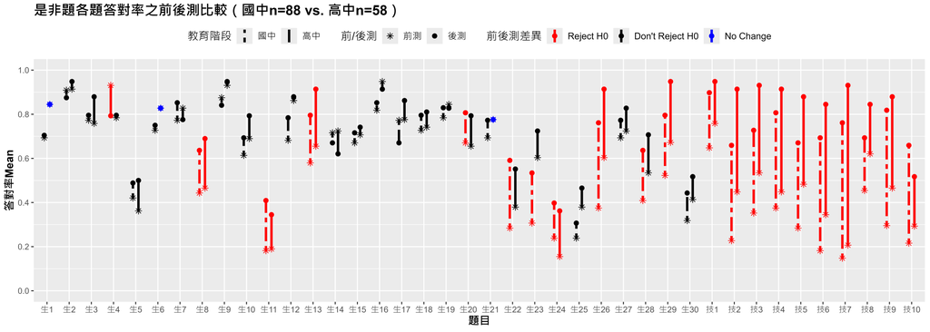

```r
# 畫圖
res_ju<-yn.prepost.table(Cdat1_yn.st.mat%>%filter(Cju), Cdat2_yn.st.mat%>%filter(Cju))
res_se<-yn.prepost.table(Cdat1_yn.st.mat%>%filter(Cse), Cdat2_yn.st.mat%>%filter(Cse))
res_edu<-rbind(res_ju, res_se)

yn.prepost.compare.plot(res_edu, "是非題各題答對率之前後測比較（國中n=88 vs. 高中n=58）", state=1)
```

從圖 1-2-3 可觀察到，各題的前後測答對率呈現多模態分布，依其變化趨勢大致可分為以下幾類：

1. **顯著進步型（學習效果佳）**  
   前測答對率偏低，後測明顯提升，顯示課程對學生有顯著幫助。例如：生 8、生 13、生 26、生28、生 29，以及所有技術類是非題。
2. **低基礎、進步有限型**  
   前測表現不佳，後測雖有進步，但整體答對率仍偏低，顯示該題難度可能過高或教學成效有限。例如：生 5、生 11、生 22、生 24、生 25、生 30。
3. **國高中表現有落差型**  
   國高中學生在前後測皆出現明顯差距，可能與教學內容未能因應學習階段差異有關（註：國高中為分班教學）。此類題目多為推論與覺察類型，例如：生 9、生 12、生 16、生 17、生 23，尤以生 17 為甚，前測國高中學生平均答對率相似，但國中生在後測出現退步情形。技術類是非題雖國高中前後測表現均有明顯落差，但進步幅度都相當顯著。
4. **表現停滯或退步型**  
   前測表現中等，但後測未見明顯進步，甚至略有退步，可能與題目敘述、命題方式或教學銜接有關。例如：生 14、生 21。
5. **高表現穩定型（課程效果不明顯）**  
   前後測皆為高答對率，進步幅度有限，且國高中表現差異不大，多為知識類題目。例如：生 1、生 2、生 6、生 7、生 9、生 18、生 19。

整體而言，第 1 類題型最能體現課程成效；第 2 類則具進步空間，教學設計可進一步強化；第 3 類顯示不同教育階段學生的吸收落差，課程內容及教學方式應視對象作調整；第 4 類則可能涉及題目本身或教學策略問題，應優先檢討；至於第 5 類，學生可能多已有先備知識，課程對其學習效果提升有限，可考慮納入更具挑戰性的內容，以提升學習潛能發揮空間。

## 1.3 按性別分組（男/女）

### 1.3.1 表1-3-1：生物題各主題分類之前後測（按性別分組）

```r
df_bio_gender <- Map(function(tp, name) {
  yn_lifes.prepost.compare.all.table(
    Cdat1_yn.st.mat%>%filter(Cboy), Cdat2_yn.st.mat%>%filter(Cboy),
    Cdat1_yn.st.mat%>%filter(!Cboy), Cdat2_yn.st.mat%>%filter(!Cboy),
    state = 4,  #性別
    type = tp,
    pair = T,
    ques_name = name,
    comparetest = T
  )
}, tp = bio$type, name = bio$ques_name) %>%
  do.call(rbind, .)

df_add_sig_stars(df_bio_gender)%>%kable("html", row.names = FALSE, escape = F,booktabs = TRUE, caption=" 全部生物是非題/知識性質與覺察分類前後測整體表現（男n=79 vs. 女n=67）",
                    digits=c(0,0,3,2,3,2,3,2,3,3,2,3,3,2,3,3,2,3))%>%
  kable_styling(c("striped", "bordered"))%>%
  add_header_above(c(" " = 2, "前測答對率" = 2, "後測答對率" = 2, "Hotelling T2檢定\n（進步量）"=3,
                     "Hotelling T2檢定\n（女性前測-男性前測）"=3,  "Hotelling T2檢定\n（女性後測-男性後測）"=3,
                     "Hotelling T2檢定\n（女性進步量-男性進步量）"=3))%>%
  column_spec(1, bold = T)%>%
  collapse_rows(columns = c(1,10:18))
```

全部生物是非題/知識性質與覺察分類前後測整體表現（男n=79 vs. 女n=67）

| 題目 | 性別 | 前測答對率 Mean | 前測答對率 SD | 後測答對率 Mean | 後測答對率 SD | Hotelling T2檢定 （進步量） Mean Diff | Hotelling T2檢定 （進步量） T2 Stat | Hotelling T2檢定 （進步量） p-value | Hotelling T2檢定 （女性前測-男性前測） Mean Diff | Hotelling T2檢定 （女性前測-男性前測） T2 Stat | Hotelling T2檢定 （女性前測-男性前測） p-value | Hotelling T2檢定 （女性後測-男性後測） Mean Diff | Hotelling T2檢定 （女性後測-男性後測） T2 Stat | Hotelling T2檢定 （女性後測-男性後測） p-value | Hotelling T2檢定 （女性進步量-男性進步量） Mean Diff | Hotelling T2檢定 （女性進步量-男性進步量） T2 Stat | Hotelling T2檢定 （女性進步量-男性進步量） p-value |  |  |  |  |  |  |  |  |  |  |
| --- | --- | --- | --- | --- | --- | --- | --- | --- | --- | --- | --- | --- | --- | --- | --- | --- | --- | --- | --- | --- | --- | --- | --- | --- | --- | --- | --- |
| 全部生物是非 | 男 | 0.618 | 0.16 | 0.711 | 0.16 | 0.094 | 232.02 | 0.000*** | 0.003 | 42.87 | 0.298 | 0.009 | 59.45 | 0.040* | 0.006 | 44.77 | 0.246 |  |  |  |  |  |  |  |  |  |  |
|  | 女 | 0.620 | 0.15 | 0.720 | 0.15 | 0.100 | 132.41 | 0.005** |  |  |  |  |  |  |  |  |  |  |  |  |  |  |  |  |  |  |  |
| 知識 | 男 | 0.716 | 0.17 | 0.773 | 0.18 | 0.057 | 51.24 | 0.000*** |  |  |  |  |  |  |  |  |  | -0.012 | 12.67 | 0.304 | -0.006 | 10.56 | 0.455 | 3.32 | 0.977 |  |  |
|  | 女 | 0.704 | 0.18 | 0.767 | 0.18 | 0.063 | 41.04 | 0.001** |  |  |  |  |  |  |  |  |  |  |  |  |  |  |  |  |  |  |  |
| 推論 | 男 | 0.636 | 0.18 | 0.727 | 0.18 | 0.091 | 97.18 | 0.000*** | 0.019 | 20.35 | 0.261 | 0.019 | 23.28 | 0.154 |  | -0.001 | 39.29 |  |  |  |  |  |  |  |  | 0.005** |  |
|  | 女 | 0.656 | 0.17 | 0.746 | 0.16 | 0.091 | 39.98 | 0.025* |  |  |  |  |  |  |  |  |  |  |  |  |  |  |  |  |  |  |  |
| 計算 | 男 | 0.365 | 0.25 | 0.539 | 0.24 | 0.175 | 29.80 | 0.000*** |  |  |  |  |  |  |  |  |  | -0.018 | 4.73 | 0.470 | 0.007 | 3.88 | 0.585 | 0.025 | 0.42 |  | 0.995 |
|  | 女 | 0.346 | 0.30 | 0.546 | 0.25 | 0.200 | 38.23 | 0.000*** |  |  |  |  |  |  |  |  |  |  |  |  |  |  |  |  |  |  |  |
| 覺察 | 男 | 0.668 | 0.19 | 0.753 | 0.19 | 0.084 | 109.51 | 0.000*** | 0.033 | 27.44 | 0.068 | 0.048 | 26.27 | 0.086 | 0.015 | 37.98 | 0.006** |  |  |  |  |  |  |  |  |  |  |
|  | 女 | 0.701 | 0.17 | 0.801 | 0.17 | 0.100 | 73.83 | 0.000*** |  |  |  |  |  |  |  |  |  |  |  |  |  |  |  |  |  |  |  |

### 1.3.2 表1-3-2：技術題各主題分類之前後測（按性別分組）

```r
df_tech_gender <- Map(function(tp, name) {
  yn_lifes.prepost.compare.all.table(
    Cdat1_yn.st.mat%>%filter(Cboy), Cdat2_yn.st.mat%>%filter(Cboy),
    Cdat1_yn.st.mat%>%filter(!Cboy), Cdat2_yn.st.mat%>%filter(!Cboy),
    state = 4,  #性別
    type = tp,
    pair = T,
    ques_name = name,
    comparetest = T
  )
}, tp = tech$type, name = tech$ques_name) %>%
  do.call(rbind, .)

df_add_sig_stars(df_tech_gender)%>%kable("html", row.names = FALSE, escape = F,booktabs = TRUE, caption=" 全部技術是非題/各技術類別前後測整體表現（男n=79 vs. 女n=67）",
                    digits=c(0,0,3,2,3,2,3,2,3,3,2,3,3,2,3,3,2,3))%>%
  kable_styling(c("striped", "bordered"))%>%
  add_header_above(c(" " = 2, "前測答對率" = 2, "後測答對率" = 2, "Hotelling T2檢定\n（進步量）"=3,
                     "Hotelling T2檢定\n（女性前測-男性前測）"=3,  "Hotelling T2檢定\n（女性後測-男性後測）"=3,
                     "Hotelling T2檢定\n（女性進步量-男性進步量）"=3))%>%
  column_spec(1, bold = T)%>%
  collapse_rows(columns = c(1,10:18))
```

全部技術是非題/各技術類別前後測整體表現（男n=79 vs. 女n=67）

| 題目 | 性別 | 前測答對率 Mean | 前測答對率 SD | 後測答對率 Mean | 後測答對率 SD | Hotelling T2檢定 （進步量） Mean Diff | Hotelling T2檢定 （進步量） T2 Stat | Hotelling T2檢定 （進步量） p-value | Hotelling T2檢定 （女性前測-男性前測） Mean Diff | Hotelling T2檢定 （女性前測-男性前測） T2 Stat | Hotelling T2檢定 （女性前測-男性前測） p-value | Hotelling T2檢定 （女性後測-男性後測） Mean Diff | Hotelling T2檢定 （女性後測-男性後測） T2 Stat | Hotelling T2檢定 （女性後測-男性後測） p-value | Hotelling T2檢定 （女性進步量-男性進步量） Mean Diff | Hotelling T2檢定 （女性進步量-男性進步量） T2 Stat | Hotelling T2檢定 （女性進步量-男性進步量） p-value |  |  |  |  |  |  |  |  |  |
| --- | --- | --- | --- | --- | --- | --- | --- | --- | --- | --- | --- | --- | --- | --- | --- | --- | --- | --- | --- | --- | --- | --- | --- | --- | --- | --- |
| 全部技術是非 | 男 | 0.382 | 0.31 | 0.781 | 0.27 | 0.399 | 146.68 | 0.000*** | -0.017 | 11.35 | 0.394 | 0.013 | 7.24 | 0.742 | 0.030 | 7.44 | 0.726 |  |  |  |  |  |  |  |  |  |
|  | 女 | 0.366 | 0.27 | 0.794 | 0.24 | 0.428 | 208.56 | 0.000*** |  |  |  |  |  |  |  |  |  |  |  |  |  |  |  |  |  |  |
| 電子感測 | 男 | 0.515 | 0.35 | 0.835 | 0.28 | 0.321 | 55.68 | 0.000*** |  |  |  |  |  |  |  |  |  | 2.61 | 0.465 | 0.050 | 2.09 | 0.561 | 0.067 | 4.01 | 0.271 |  |
|  | 女 | 0.498 | 0.36 | 0.886 | 0.24 | 0.388 | 67.01 | 0.000*** |  |  |  |  |  |  |  |  |  |  |  |  |  |  |  |  |  |  |
| Arduino | 男 | 0.291 | 0.35 | 0.772 | 0.31 | 0.481 | 131.20 | 0.000*** |  | -0.037 | 2.15 | 0.717 | 0.004 | 1.52 | 0.828 | 0.041 | 1.78 |  |  |  |  |  |  |  |  | 0.783 |
|  | 女 | 0.254 | 0.30 | 0.776 | 0.28 | 0.522 | 160.08 | 0.000*** |  |  |  |  |  |  |  |  |  |  |  |  |  |  |  |  |  |  |
| 程式 | 男 | 0.371 | 0.39 | 0.738 | 0.33 | 0.367 | 61.10 | 0.000*** |  |  |  |  |  |  |  |  |  | 0.012 | 7.07 | 0.077 | -0.012 | 2.61 | 0.465 | -0.024 | 0.626 |  |
|  | 女 | 0.383 | 0.37 | 0.726 | 0.32 | 0.343 | 54.29 | 0.000*** |  |  |  |  |  |  |  |  |  |  |  |  |  |  |  |  |  |  |

### 1.3.3 圖1-3-3：各題答對率（按性別分組）

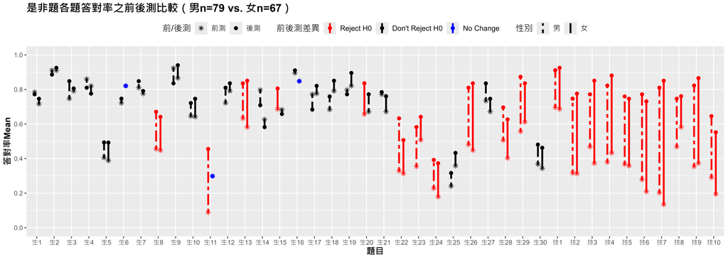

```r
# 畫圖
res_boy<-yn.prepost.table(Cdat1_yn.st.mat%>%filter(Cboy), Cdat2_yn.st.mat%>%filter(Cboy))
res_girl<-yn.prepost.table(Cdat1_yn.st.mat%>%filter(!Cboy), Cdat2_yn.st.mat%>%filter(!Cboy))
res_gender<-rbind(res_boy, res_girl)

yn.prepost.compare.plot(res_gender, "是非題各題答對率之前後測比較（男n=79 vs. 女n=67）", state=4)
```

從圖 1-3-3 可觀察到，男女學生在各題的表現趨勢與圖 1 所呈現的國高中差異有所不同，顯示性別在學習反應上的特性亦值得探討。依據逐題答對率變化，可歸納出以下幾類圖 1 中未出現的特徵型態：

1. **兩性表現有落差型**  
   男女在前後測皆出現明顯差距，可能與先天認知差異、學習風格或專注度等因素相關。例如：生 14、生 15、生 17、生 18、生 19、生 25。值得注意的是，技術類是非題在兩性表現上差異則相對較小，顯示技術題對性別影響較不敏感。
2. **高表現穩定型（課程效果不明顯）**  
   前後測皆為高答對率，進步幅度有限，且男女表現差異不大，主要集中於知識性題目。例如：生 1、生 2、生 3、生 4、生 6、生 7、生 16。

整體而言，圖 1-3-3 所揭示的性別差異雖不如國高中差異顯著普遍，但仍有部分題目呈現穩定的性別落差，應視為後續教學設計的重要參考依據。對於第 1 類的題目，建議深入探討其內容是否隱含性別偏向，或是否需調整教學策略以提升學習公平性；至於第 2 類，則與圖 1 類似，可能反映學生已有先備知識，課程未能進一步促進其學習成長，未來可考慮設計延伸性挑戰題以拓展其學習深度。

## 1.4 按早餐熱量需求分組（高熱量攝取/非高熱量攝取）

以下為根據「早餐學習單」資料進行之分組說明。由於該資料並非與問卷同步收集，故實際可用樣本數與問卷資料略有出入。本次分組依據學習單中「當天早餐總熱量」欄位進行，並以 500 大卡作為分界：攝取熱量達 500 大卡以上者歸為「高熱量攝取組」（共 23 人），未達者歸為「非高熱量攝取組」（共 86 人）。

儘管兩組樣本人數差距較大，考量高熱量攝取可能與個體代謝能力及肥胖風險具一定關聯性，因此我們採此標準進行分組，並視為研究設計中可接受之差異。

### 1.4.1 表1-4-1：生物題各主題分類之前後測（按早餐熱量需求分組）

```r
df_bio_heat <- Map(function(tp, name) {
  yn_lifes.prepost.compare.all.table(
    Cdat1_yn.st.mat%>%filter(Cfat.bf), Cdat2_yn.st.mat%>%filter(Cfat.bf),
    Cdat1_yn.st.mat%>%filter(Cnofat.bf), Cdat2_yn.st.mat%>%filter(Cnofat.bf),
    state = 3,  #早餐熱量需求（高熱量：>=500kcal，非高熱量：<500kcal）
    type = tp,
    pair = T,
    ques_name = name,
    comparetest = T
  )
}, tp = bio$type, name = bio$ques_name) %>%
  do.call(rbind, .)

df_add_sig_stars(df_bio_heat)%>%kable("html", row.names = FALSE, escape = F,booktabs = TRUE, caption=" 全部生物是非題/知識性質與覺察分類前後測整體表現（早餐高熱量攝取組n=23 vs. 早餐非高熱量攝取組n=86）",
                    digits=c(0,0,3,2,3,2,3,2,3,3,2,3,3,2,3,3,2,3))%>%
  kable_styling(c("striped", "bordered"))%>%
  add_header_above(c(" " = 2, "前測答對率" = 2, "後測答對率" = 2, "Hotelling T2檢定\n（進步量）"=3,
                     "Hotelling T2檢定\n（高熱量組前測-非高熱量組前測）"=3,  "Hotelling T2檢定\n（高熱量組後測-非高熱量組後測）"=3,
                     "Hotelling T2檢定\n（高熱量組進步量-非高熱量組進步量）"=3))%>%
  column_spec(1, bold = T)%>%
  collapse_rows(columns = c(1,10:18))
```

全部生物是非題/知識性質與覺察分類前後測整體表現（早餐高熱量攝取組n=23 vs. 早餐非高熱量攝取組n=86）

| 題目 | 早餐熱量需求 | 前測答對率 Mean | 前測答對率 SD | 後測答對率 Mean | 後測答對率 SD | Hotelling T2檢定 （進步量） Mean Diff | Hotelling T2檢定 （進步量） T2 Stat | Hotelling T2檢定 （進步量） p-value | Hotelling T2檢定 （高熱量組前測-非高熱量組前測） Mean Diff | Hotelling T2檢定 （高熱量組前測-非高熱量組前測） T2 Stat | Hotelling T2檢定 （高熱量組前測-非高熱量組前測） p-value | Hotelling T2檢定 （高熱量組後測-非高熱量組後測） Mean Diff | Hotelling T2檢定 （高熱量組後測-非高熱量組後測） T2 Stat | Hotelling T2檢定 （高熱量組後測-非高熱量組後測） p-value | Hotelling T2檢定 （高熱量組進步量-非高熱量組進步量） Mean Diff | Hotelling T2檢定 （高熱量組進步量-非高熱量組進步量） T2 Stat | Hotelling T2檢定 （高熱量組進步量-非高熱量組進步量） p-value |  |  |  |  |  |  |  |  |  |  |  |  | … |
| --- | --- | --- | --- | --- | --- | --- | --- | --- | --- | --- | --- | --- | --- | --- | --- | --- | --- | --- | --- | --- | --- | --- | --- | --- | --- | --- | --- | --- | --- | --- |
| 全部生物是非 | 高熱量 | 0.636 | 0.12 | 0.697 | 0.18 | 0.061 | 1304.93 | 0.140 | 0.019 | 2.33 | 0.446 | -0.025 | 1.40 | 0.925 | -0.044 | 1.60 | 0.847 |  |  |  |  |  |  |  |  |  |  |  |  | … |
|  | 非高熱量 | 0.617 | 0.17 | 0.722 | 0.16 | 0.105 | 193.91 | 0.000*** |  |  |  |  |  |  |  |  |  |  |  |  |  |  |  |  |  |  |  |  |  | … |
| 知識 | 高熱量 | 0.713 | 0.15 | 0.774 | 0.21 | 0.061 | 32.94 | 0.130 |  |  |  |  |  |  |  |  |  | 0.003 | 13.40 | 0.284 | 0.009 | 6.58 | 0.800 | 0.006 | 7.67 | 0.720 |  |  |  | … |
|  | 非高熱量 | 0.710 | 0.19 | 0.765 | 0.19 | 0.055 | 51.82 | 0.000*** |  |  |  |  |  |  |  |  |  |  |  |  |  |  |  |  |  |  |  |  |  | … |
| 推論 | 高熱量 | 0.675 | 0.13 | 0.728 | 0.20 | 0.052 | 44.82 | 0.473 | 0.037 | 18.10 | 0.433 | -0.017 | 13.36 | 0.695 | -0.054 | 11.03 | 0.835 |  |  |  |  |  |  |  |  |  |  |  |  | … |
|  | 非高熱量 | 0.638 | 0.19 | 0.744 | 0.18 | 0.106 | 71.76 | 0.000*** |  |  |  |  |  |  |  |  |  |  |  |  |  |  |  |  |  |  |  |  |  | … |
| 計算 | 高熱量 | 0.365 | 0.27 | 0.452 | 0.30 | 0.087 | 3.56 | 0.713 |  |  |  |  |  |  |  |  |  |  |  |  |  |  |  |  |  |  | -0.002 | 7.71 | 0.202 | … |
|  | 非高熱量 | 0.367 | 0.26 | 0.567 | 0.23 | 0.200 | 52.51 | 0.000*** |  |  |  |  |  |  |  |  |  |  |  |  |  |  |  |  |  |  |  |  |  | … |
| 覺察 | 高熱量 | 0.681 | 0.15 | 0.730 | 0.19 | 0.049 | 94.52 | 0.119 | 0.006 | 14.60 | 0.625 | -0.056 | 6.46 | 0.977 | -0.062 | 16.49 | 0.508 |  |  |  |  |  |  |  |  |  |  |  |  | … |
|  | 非高熱量 | 0.675 | 0.20 | 0.786 | 0.20 | 0.111 | 92.30 | 0.000*** |  |  |  |  |  |  |  |  |  |  |  |  |  |  |  |  |  |  |  |  |  | … |

### 1.4.2 表1-4-2：技術題各主題分類之前後測（按早餐熱量需求分組）

```r
df_tech_heat <- Map(function(tp, name) {
  yn_lifes.prepost.compare.all.table(
    Cdat1_yn.st.mat%>%filter(Cfat.bf), Cdat2_yn.st.mat%>%filter(Cfat.bf),
    Cdat1_yn.st.mat%>%filter(Cnofat.bf), Cdat2_yn.st.mat%>%filter(Cnofat.bf),
    state = 3,  #早餐熱量需求（高熱量：>=500kcal，非高熱量：<500kcal）
    type = tp,
    pair = T,
    ques_name = name,
    comparetest = T
  )
}, tp = tech$type, name = tech$ques_name) %>%
  do.call(rbind, .)

df_add_sig_stars(df_tech_heat)%>%kable("html", row.names = FALSE, escape = F,booktabs = TRUE, caption=" 全部技術是非題/各技術類別前後測整體表現（早餐高熱量攝取組n=23 vs. 早餐非高熱量攝取組n=86）",
                    digits=c(0,0,3,2,3,2,3,2,3,3,2,3,3,2,3,3,2,3))%>%
  kable_styling(c("striped", "bordered"))%>%
  add_header_above(c(" " = 2, "前測答對率" = 2, "後測答對率" = 2, "Hotelling T2檢定\n（進步量）"=3,
                     "Hotelling T2檢定\n（高熱量組組前測-非高熱量組前測）"=3,  "Hotelling T2檢定\n（高熱量組後測-非高熱量組後測）"=3,
                     "Hotelling T2檢定\n（高熱量組進步量-非高熱量組進步量）"=3))%>%
  column_spec(1, bold = T)%>%
  collapse_rows(columns = c(1,10:18))
```

全部技術是非題/各技術類別前後測整體表現（早餐高熱量攝取組n=23 vs. 早餐非高熱量攝取組n=86）

| 題目 | 早餐熱量需求 | 前測答對率 Mean | 前測答對率 SD | 後測答對率 Mean | 後測答對率 SD | Hotelling T2檢定 （進步量） Mean Diff | Hotelling T2檢定 （進步量） T2 Stat | Hotelling T2檢定 （進步量） p-value | Hotelling T2檢定 （高熱量組組前測-非高熱量組前測） Mean Diff | Hotelling T2檢定 （高熱量組組前測-非高熱量組前測） T2 Stat | Hotelling T2檢定 （高熱量組組前測-非高熱量組前測） p-value | Hotelling T2檢定 （高熱量組後測-非高熱量組後測） Mean Diff | Hotelling T2檢定 （高熱量組後測-非高熱量組後測） T2 Stat | Hotelling T2檢定 （高熱量組後測-非高熱量組後測） p-value | Hotelling T2檢定 （高熱量組進步量-非高熱量組進步量） Mean Diff | Hotelling T2檢定 （高熱量組進步量-非高熱量組進步量） T2 Stat | Hotelling T2檢定 （高熱量組進步量-非高熱量組進步量） p-value |  |  |  |  |  |  |  |  |  |  |  |  | … |
| --- | --- | --- | --- | --- | --- | --- | --- | --- | --- | --- | --- | --- | --- | --- | --- | --- | --- | --- | --- | --- | --- | --- | --- | --- | --- | --- | --- | --- | --- | --- |
| 全部技術是非 | 高熱量 | 0.296 | 0.29 | 0.726 | 0.34 | 0.430 | 61.61 | 0.016* | -0.096 | 24.55 | 0.037* | -0.075 | 13.89 | 0.289 | 0.021 | 4.63 | 0.932 |  |  |  |  |  |  |  |  |  |  |  |  | … |
|  | 非高熱量 | 0.392 | 0.30 | 0.801 | 0.23 | 0.409 | 223.58 | 0.000*** |  |  |  |  |  |  |  |  |  |  |  |  |  |  |  |  |  |  |  |  |  | … |
| 電子感測 | 高熱量 | 0.420 | 0.37 | 0.797 | 0.34 | 0.377 | 20.11 | 0.004** |  |  |  |  |  |  |  |  |  | -0.095 | 4.30 | 0.245 | -0.067 | 2.55 | 0.478 | 0.028 | 0.63 | 0.892 |  |  |  | … |
|  | 非高熱量 | 0.516 | 0.36 | 0.864 | 0.24 | 0.349 | 78.23 | 0.000*** |  |  |  |  |  |  |  |  |  |  |  |  |  |  |  |  |  |  |  |  |  | … |
| Arduino | 高熱量 | 0.217 | 0.31 | 0.707 | 0.34 | 0.489 | 49.94 | 0.000*** | -0.079 | 4.51 | 0.373 | -0.096 | 4.09 | 0.415 | -0.017 | 3.18 | 0.545 |  |  |  |  |  |  |  |  |  |  |  |  | … |
|  | 非高熱量 | 0.297 | 0.33 | 0.802 | 0.28 | 0.506 | 184.34 | 0.000*** |  |  |  |  |  |  |  |  |  |  |  |  |  |  |  |  |  |  |  |  |  | … |
| 程式 | 高熱量 | 0.275 | 0.37 | 0.681 | 0.41 | 0.406 | 26.28 | 0.001** |  |  |  |  |  |  |  |  |  |  |  |  |  |  |  |  |  |  | -0.120 | 5.82 | 0.133 | … |
|  | 非高熱量 | 0.395 | 0.38 | 0.736 | 0.32 | 0.341 | 80.25 | 0.000*** |  |  |  |  |  |  |  |  |  |  |  |  |  |  |  |  |  |  |  |  |  | … |

綜合來看，高熱量攝取者在生物領域的學習成效相對較弱，可能與其既有的錯誤知識或認知偏誤有關；但在技術題型中，早餐熱量攝取對學習成效的影響則相對有限，顯示技術學習或許較不受其生理或認知背景干擾。

### 1.4.3 圖1-4-3：各題答對率（按早餐熱量需求分組）

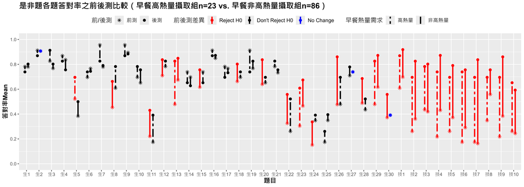

```r
# 畫圖
res_fat<-yn.prepost.table(Cdat1_yn.st.mat%>%filter(Cfat.bf), Cdat2_yn.st.mat%>%filter(Cfat.bf))
res_nofat<-yn.prepost.table(Cdat1_yn.st.mat%>%filter(Cnofat.bf), Cdat2_yn.st.mat%>%filter(Cnofat.bf))
res_heat<-rbind(res_fat, res_nofat)

yn.prepost.compare.plot(res_heat, "是非題各題答對率之前後測比較（早餐高熱量攝取組n=23 vs. 早餐非高熱量攝取組n=86）", state=3)
```

從圖 3 可觀察到，不同熱量需求分組在各題的表現趨勢，與圖 1（教育階段分組）與圖 2（性別分組）所呈現的差異有所不同，顯示「早餐熱量需求」作為一項生理與行為相關變項，在學習反應上亦具有其探討價值。根據逐題答對率的變化型態，可歸納出以下幾種圖 1、圖 2 中未明顯出現的特徵分類：

整體而言，圖 3 顯示早餐熱量攝取與學習表現具一定關聯。第 1 類題目具補足知識落差之效，可強化基礎教學；第 2 類可能代表該組學生具備良好先備知識或學習資源，或此類題目特別貼近其生活經驗；第 3 類顯示課程未有效改善其錯誤認知，或教學方式未能對應其學習方式與需求，應檢討教學策略；第 4 類則可能是題目本身存在設計瑕疵，如題幹不清楚、選項模糊，或與課程內容銜接不足，宜優先修訂。此圖為課程設計與學習差異理解提供另一重要面向。

# 2 題項（鑑別度、難度、信度）分析

在問卷或教育測驗研究中，題項分析（item analysis）為確保測驗品質的重要步驟。透過對各題的難度（difficulty）、鑑別度（discrimination）以及整體信度（reliability）進行評估，研究者能有效辨識出哪些題目能夠準確區分受試者能力，哪些題目可能過於簡單、模糊，或無助於整體測量效能。這不僅有助於優化問卷題項設計，也可作為後續教學修正或教材改善的依據。

為提供完整的題項診斷，本研究將採用多項指標來評估問卷中是非題的測量品質。以下將逐一介紹分析項目、其定義與意義，以及在本研究中如何進行計算（包含使用的 R 套件與自定義公式）：

分析項目

指標意義與解釋

計算方式與來源

**難度（Difficulty）**

根據古典測驗理論（Classical Test Theory，難度為題目被答對的比例，數值越高表示越容易。本研究採用較具區辨力的定義，即高分組與低分組之答對率平均，難度值介於 0.5~0.8 較為理想。

自行計算：*(高分組答對率 + 低分組答對率) / 2*

**鑑別度（Discrimination）**

包含兩種常見指標：

1. 分組鑑別度：可衡量題目對高低能力受試者之區分能力，反映該題對區分學生能力的效度，數值越高代表區分力越佳。
2. 點二列相關(pBis) ：題目得分（對/錯）與總測驗得分之相關，衡量該題與整體測驗的一致性與鑑別性。
1. 分組鑑別度：*高分組答對率-低分組答對率*
2. pBis：`CTT::itemAnalysis$pBis`

**臨界比（Critical Ratio, CR）**

利用雙樣本 t 檢定比較高低分組答對率是否具統計差異，對應的統計量為 CR 值，並搭配 p-value 判斷顯著性。若 CR 值小或 p-value 大，表示區辨力可能不足。

自行計算：*two-sample independent t-test*，輸出 CR值與 p-value

**alpha信度（Cronbach’s α）**

本研究採用Cronbach’s α 作為信度指標，衡量整體測驗題目的內部一致性，數值越高表示測驗穩定性與一致性越佳。Cronbach’s α 值大於 0.7 通常視為可接受。

`CTT::itemAnalysis$alpha`

**刪題後alpha信度（Item-deleted Alpha）**

每刪除一題後重新估算整體 α 值，觀察該題對整體一致性的影響。若刪題後 α 值提高，表示該題可能與其他題不一致，建議進一步檢討或移除。

`CTT::itemAnalysis$itemreport$alphaIfDeleted`

## 2.1 是非題

在有前後測資料的研究設計中，題項分析可分別發揮不同功能：**前測資料**可用來檢視題目在無教學介入前是否具備基本的區辨能力，適合用於判斷「原始題目品質」；**後測資料**則反映學生學習後的反應與知識吸收，適合用於檢視「教學後測驗的功能性與反映效果」。二者相輔相成，能提供更完整的診斷依據。

由於本研究是在教學活動結束、後測資料回收完畢後才啟動分析流程，故主要題項分析將以**後測資料為主**，以評估各題在測驗最終階段的表現。不過，為了更全面理解學生學習歷程與題目效果，後續亦將呈現各題難度與鑑別度的前後測變化圖，作為補充說明與延伸觀察。

一般套件依得分分成高分組低分組採用的比例是得分最高/最低的前25%，由於我們資料量較少，為了更加平衡高分組與低分組的人數，使用前30%作為分組區分點。以下為題項分析之結果。

```r
library(glue)
type<-"後測是非題總得分";group_ratio<-0.3
upper = quantile(Cdat2_yn$總得分,1-group_ratio)+2.5; upper_num = upper/2.5
lower = quantile(Cdat2_yn$總得分,group_ratio); lower_num = lower/2.5

out<-matrix(NA,3,3)
rownames(out)<-c("高分組","平均組","低分組")
colnames(out)<-c("分組依據",type,"組內人數")

out[1,1]<-glue("{type}的前 {group_ratio*100} %")
out[2,1]<-glue("{type}的平均上下 {(1-2*group_ratio)*100} %")
out[3,1]<-glue("{type}的後 {group_ratio*100} %")


out[1,2]<-glue("{upper} 分(含)以上（答對 {upper_num} 題以上）")
out[2,2]<-glue("{lower+2.5} ~ {upper-2.5} 分（答對 {lower_num+1} ~ {upper_num-1} 題）")
out[3,2]<-glue("{lower} 分(含)以下（答對 {lower_num} 題以下）")


gpost.high<-rowSums(Cdat2_yn.st.mat)>=upper_num
gpost.low<-rowSums(Cdat2_yn.st.mat)<=lower_num

out[1,3]<-length(which(gpost.high));out[3,3]<-length(which(gpost.low))
out[2,3]<-dim(Cdat2_yn)[1]-length(which(gpost.high))-length(which(gpost.low))

out%>%kable("html",escape = F,booktabs = TRUE, caption = " 後測是非題總得分之分組敘述統計")%>%
  kable_styling(c("striped", "bordered"))%>%
  column_spec(1, bold = T)
```

後測是非題總得分之分組敘述統計

|  | 分組依據 | 後測是非題總得分 | 組內人數 |
| --- | --- | --- | --- |
| 高分組 | 後測是非題總得分的前 30 % | 85 分(含)以上（答對 34 題以上） | 39 |
| 平均組 | 後測是非題總得分的平均上下 40 % | 70 ~ 82.5 分（答對 28 ~ 33 題） | 62 |
| 低分組 | 後測是非題總得分的後 30 % | 67.5 分(含)以下（答對 27 題以下） | 45 |

### 2.1.1 表2-1-1：生物/技術是非題之題項分析

```r
# sjPlot::tab_itemscale(Cdat2_yn.st.mat)
res = item_anal(Cdat2_yn.st.mat, group_ratio = 0.3)

res %>% df_add_sig_stars() %>%
  kable("html", row.names = TRUE, escape = F,booktabs = TRUE, caption=" 生物/技術是非題之題項分析",
                    digits=c(3,3,3,3,3,2,3,3))%>%
  kable_styling(c("striped", "bordered"))%>%
  add_header_above(c(" " = 1, "答對率 Mean" = 2, "難度分析" = 1, "鑑別度分析"=4,
                     "信度分析"=1))%>%
  column_spec(1, bold = T) %>%
  add_footnote(paste0("整體信度 Cronbach's Alpha : ", res[[1]]%>%round(4), " ，刪題後alpha若超過此值以 # 加註", sep=""), notation = "none")
```

生物/技術是非題之題項分析

|  | 答對率 Mean 低分組 | 答對率 Mean 高分組 | 難度分析 分組難度 | 鑑別度分析 分組鑑別度 | 鑑別度分析 pBis | 鑑別度分析 CR值 | 鑑別度分析 p-value | 信度分析 刪題後alpha |
| --- | --- | --- | --- | --- | --- | --- | --- | --- |
| 生1 | 0.622 | 1.000 | 0.811 | 0.378 | 0.284 | 5.17 | 0.000*** | 0.837 |
| 生2 | 0.756 | 1.000 | 0.878 | 0.244 | 0.350 | 3.77 | 0.000*** | 0.836 |
| 生3 | 0.733 | 0.974 | 0.854 | 0.241 | 0.215 | 3.37 | 0.001** | 0.839 |
| 生4 | 0.689 | 0.949 | 0.819 | 0.260 | 0.188 | 3.31 | 0.002** | 0.839 |
| 生5 | 0.467 | 0.641 | 0.554 | 0.174 | 0.017 | 1.61 | 0.112 | 0.845 # |
| 生6 | 0.644 | 0.923 | 0.784 | 0.279 | 0.309 | 3.31 | 0.001** | 0.837 |
| 生7 | 0.689 | 0.923 | 0.806 | 0.234 | 0.261 | 2.85 | 0.006** | 0.838 |
| 生8 | 0.489 | 0.923 | 0.706 | 0.434 | 0.326 | 5.00 | 0.000*** | 0.836 |
| 生9 | 0.756 | 0.949 | 0.852 | 0.193 | 0.313 | 2.61 | 0.011* | 0.837 |
| 生10 | 0.489 | 0.923 | 0.706 | 0.434 | 0.281 | 5.00 | 0.000*** | 0.837 |
| 生11 | 0.244 | 0.590 | 0.417 | 0.345 | 0.161 | 3.39 | 0.001** | 0.841 # |
| 生12 | 0.600 | 1.000 | 0.800 | 0.400 | 0.457 | 5.42 | 0.000*** | 0.833 |
| 生13 | 0.644 | 1.000 | 0.822 | 0.356 | 0.381 | 4.93 | 0.000*** | 0.835 |
| 生14 | 0.444 | 0.795 | 0.620 | 0.350 | 0.264 | 3.47 | 0.001*** | 0.838 |
| 生15 | 0.578 | 0.923 | 0.750 | 0.345 | 0.224 | 4.01 | 0.000*** | 0.839 |
| 生16 | 0.711 | 1.000 | 0.856 | 0.289 | 0.297 | 4.23 | 0.000*** | 0.837 |
| 生17 | 0.533 | 0.897 | 0.715 | 0.364 | 0.342 | 4.05 | 0.000*** | 0.836 |
| 生18 | 0.578 | 1.000 | 0.789 | 0.422 | 0.372 | 5.67 | 0.000*** | 0.835 |
| 生19 | 0.689 | 0.974 | 0.832 | 0.285 | 0.333 | 3.84 | 0.000*** | 0.836 |
| 生20 | 0.644 | 0.872 | 0.758 | 0.227 | 0.234 | 2.52 | 0.014* | 0.838 |
| 生21 | 0.644 | 0.923 | 0.784 | 0.279 | 0.267 | 3.31 | 0.001** | 0.838 |
| 生22 | 0.378 | 0.641 | 0.509 | 0.263 | 0.245 | 2.46 | 0.016* | 0.839 |
| 生23 | 0.533 | 0.769 | 0.651 | 0.236 | 0.126 | 2.29 | 0.024* | 0.842 # |
| 生24 | 0.333 | 0.487 | 0.410 | 0.154 | 0.071 | 1.43 | 0.156 | 0.844 # |
| 生25 | 0.222 | 0.410 | 0.316 | 0.188 | 0.104 | 1.88 | 0.064 | 0.843 # |
| 生26 | 0.489 | 0.974 | 0.732 | 0.485 | 0.559 | 6.10 | 0.000*** | 0.831 |
| 生27 | 0.578 | 1.000 | 0.789 | 0.422 | 0.491 | 5.67 | 0.000*** | 0.832 |
| 生28 | 0.378 | 0.821 | 0.599 | 0.443 | 0.372 | 4.54 | 0.000*** | 0.835 |
| 生29 | 0.600 | 1.000 | 0.800 | 0.400 | 0.497 | 5.42 | 0.000*** | 0.833 |
| 生30 | 0.289 | 0.718 | 0.503 | 0.429 | 0.301 | 4.29 | 0.000*** | 0.837 |
| 技1 | 0.733 | 1.000 | 0.867 | 0.267 | 0.542 | 4.00 | 0.000*** | 0.833 |
| 技2 | 0.533 | 0.923 | 0.728 | 0.390 | 0.376 | 4.49 | 0.000*** | 0.835 |
| 技3 | 0.511 | 0.949 | 0.730 | 0.438 | 0.484 | 5.25 | 0.000*** | 0.832 |
| 技4 | 0.644 | 0.949 | 0.797 | 0.304 | 0.454 | 3.78 | 0.000*** | 0.833 |
| 技5 | 0.444 | 0.923 | 0.684 | 0.479 | 0.492 | 5.53 | 0.000*** | 0.832 |
| 技6 | 0.467 | 0.897 | 0.682 | 0.431 | 0.364 | 4.79 | 0.000*** | 0.835 |
| 技7 | 0.600 | 0.923 | 0.762 | 0.323 | 0.456 | 3.78 | 0.000*** | 0.833 |
| 技8 | 0.467 | 0.974 | 0.721 | 0.508 | 0.448 | 6.39 | 0.000*** | 0.833 |
| 技9 | 0.578 | 1.000 | 0.789 | 0.422 | 0.567 | 5.67 | 0.000*** | 0.831 |
| 技10 | 0.400 | 0.846 | 0.623 | 0.446 | 0.216 | 4.63 | 0.000*** | 0.839 |

整體信度 Cronbach’s Alpha : 0.8399 ，刪題後alpha若超過此值以 # 加註

### 2.1.2 圖2-1-2：生物/技術是非題各題 pBis鑑別度 與 難度 之前後測變化

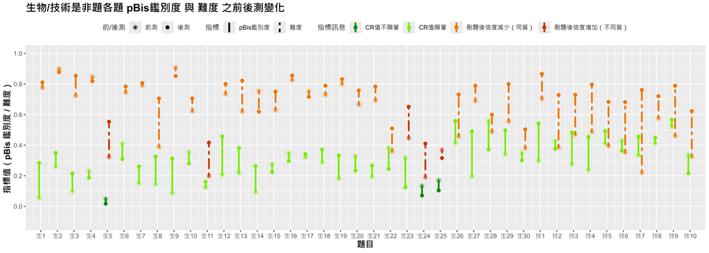

```r
item_anal_plot(Cdat1_yn.st.mat, Cdat2_yn.st.mat, group_ratio = 0.3, title = "生物/技術是非題各題 pBis鑑別度 與 難度 之前後測變化")
```

綜合表 2-1-1 與圖 2-1-2 的分析結果可發現，多數題目在難度、鑑別度與信度三項指標上呈現高度一致的特徵。其中，生 5、生 11、生 24、生 25 等題目尤需特別關注，這些題目同時符合以下現象：分組難度值偏低（<0.6，代表偏難）、pBis 鑑別度在前後測變化極小或後測反而退步、刪除該題後整體信度提升，顯示此類題目本身設計可能存在問題。

值得注意的是，這些題目亦在前述針對不同主題與族群所進行的答對率分析中，皆被歸類為「低基礎、進步有限型」，進一步支持其教學效果不佳可能與題目本身設計瑕疵有關。因此，建議將此類題目列為優先修訂或剔除對象。

整體而言，本份問卷的「是非題」在後測階段整體難度偏易，多數題目的後測難度值接近 0.8。生物類是非題的鑑別度普遍較低，近半數題目在 pBis 鑑別度呈現進步幅度小於 0.1 或甚至倒退，顯示此類題目在教學後的區辨效力有限。相對地，非上述前列的計算題（生 26、生 28、生 30）以及所有技術類題目之 pBis 鑑別度表現較佳，平均皆達 0.4 以上，且後測進步幅度明顯，顯示與實作或計算相關的課程內容較能有效提升學生理解與能力表現。